# DASC1 Report, Justus Reiffs, Jan Pinto Strohhäusl

This report was written to gather a better insight about general educational data about countries in Europe.

This report is divided into two major parts:  
- The first part, which contains various data tidying and visualizations by both Justus and Jan  
- The second part, which is written individually and contains the regression

We will now start with the first part. Here, each person wrote a little section about the process of tidying and visualisation. The creator of each section is mentioned in the title of the section.

## 1. Early Leavers in Germany, differences in genders since 2000 - written by Justus Reiffs

This Part is used to compare the developement of school early leavers for the time since 2000 till 2019 for women and men.

### 1.1 Set up / Gather Data

To start we need to import the library. The library stores the commands which are used to handle the data.

```r
library(tidyverse)
```

Here the Dataset is imported, so it is possible to access the information from it.

```r
info <- read.csv("qog_eureg_wide1_nov20.csv")
```

Then before visualisation the data gets filtered. To start that only the information of those rows is accesed which have the region name GERMANY. Second, the information is selected so that there is region name and the the year available. Further, the limits are being set. Therefore, we filter futher that only the values we need are available. They are also filtered for the data from the “nuts0” part. Then the separat steps get combined so there is only one variable is needed to access the information.

```r
germaninfo <- filter(info, region_name == "GERMANY")

specef <- select(germaninfo, region_name, year)

filtered <- select(germaninfo, eu_eduleave_m_nuts0:eu_eduleave_f_nuts0)

filtered <- select(filtered, ends_with("nuts0"))

merged <- bind_cols(specef, filtered)

merged <- filter(merged, year >= 2000 & year < 2019)
```

### 1.2 Display diagramm

After the data is available and tidy so that it is more practical the plot can be build. So this following code will generate a plot that shows the the developement of the data.

[figure not shown]

```r
ggplot(data = merged) +
  geom_line(mapping = aes(x = year, y = eu_eduleave_m_nuts0, color = "Female")) +
  geom_line(mapping = aes(x = year, y = eu_eduleave_f_nuts0, color = "Male")) +
  scale_color_manual(name = "Gender", values = c("Female" = "blue", "Male" = "red")) +
  ggtitle("Comparison of erlylevers in education for Female and male") +
  xlab("Time in years(2000-2019)") +
  ylab("Percentage of erly levers")
```

## 2. Amount of early leavers in Europe - written by Jan Pinto Strohhäusl

This part will focus on the amount of young people aged 18 - 24, which left any education and training and are not participating in any education and training.

### 2.1 Gather and tidy data

Before generating a diagram and discussing it, we first need to gather the relating data. We first import the `tidyverse`-library, because this library is the most common library used to transform and visualize data:

```r
library(tidyverse)
```

Then, we import the dataset from the CSV-File in our `alldata1`-variable:

```r
alldata1 <- read_csv("qog_eureg_wide1_nov20.csv")
```

Now that we have our data, we first need set a specific year, because we do not want to see a change over time, but data from a specific year. To accomodate missing data, I chose the year 2015, because that is a fairly new year, so that data is still relevant. Also, the reason I chose 2015 is because the years after 2015 tend to lack data, so I settled at 2015 to just to be sure that there will be data:

```r
limited1 <- filter(alldata1, year == 2015)
```

Then, we can filter out the columns we need. That would be the country name, the two-letter code of the country and the column that holds the data:

```r
filtered1 <- select(limited1, region_name, region_code, eu_eduleave_t_nuts0)
```

We only want to use countries that have data, so we delete all countries from the dataframe that have no data for that specific context:

```r
final1 <- filtered1 %>% filter_all(all_vars(!is.na(.)))
```

Conveniantly, this also deletes rows that were specified to hold data about regions. However, they are not needed here.  
For the last step, we need to create a new row in our dataframe. This way, we can later in the diagram generate a legend.

```r
final1$region_code_name <- paste(final1$region_code, ":", final1$region_name)
```

Now that we have our final dataframe, we can then generate the diagram.

### 2.2 Display diagram

The following code will generate a bar chart diagram. The reason why it is a bar chart is so we can clearly see the differences between countries:

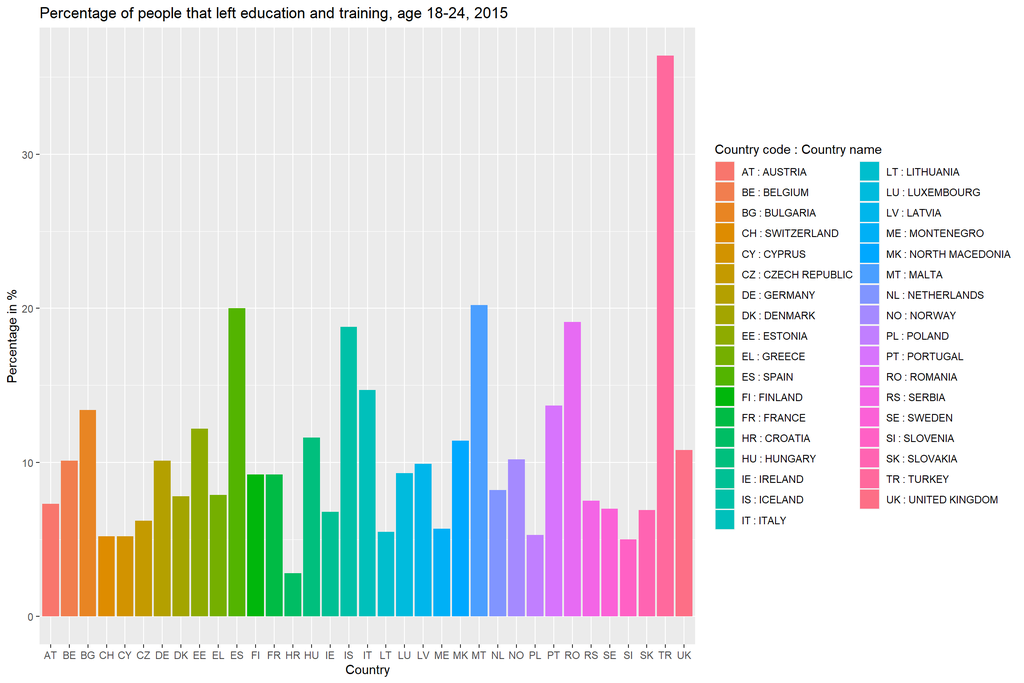

```r
ggplot(data = final1, aes(x = region_code, y = eu_eduleave_t_nuts0, fill = region_code_name)) +
    geom_bar(stat = "identity") +
    xlab("Country") +
    ylab("Percentage in %") +
    ggtitle("Percentage of people that left education and training, age 18-24, 2015") +
    guides(fill = guide_legend(title = "Country code : Country name"))
```

Here, we see that most of the countries are fairly near to each other. However, Turkey is the country with the most young people who left education and training. As a contrast, Croatia has most of its young people in education and training. As a matter of fact, most balkan countries are in the lower area of the bar chart. For me, there is not a apparent reason for that. Maybe they are more engaged to get a higher degree as other countries, so they can live a better life, or they are learning earlier how to craft, so they have early a secure job.

## 3. Employment rate for age between 15-34 in Europe - written by Justus Reiffs

In this part the Employment rate for Germany, France, Netherlands and Poland is going to be compared.

### 3.1 Set up / Gather Data

First, it is important to load the library. In this case it is the tidyverse library.

```r
library(tidyverse)
```

Here the dataset is accessed and read. The information is stored in the variable “info”.

```r
info <- read.csv("qog_eureg_wide1_nov20.csv")
```

To continue the data needs to be tidy. So in this case the data for each country gets filtered and stored in an own variable. After that the information for each country gets selected and specified further.

```r
ger <- filter(info, region_name == "GERMANY")
fr <- filter(info, region_name == "FRANCE")
nl <- filter(info, region_name == "NETHERLANDS")
pl <- filter(info, region_name == "POLAND")

gerinfo <- select(ger, region_name, year)
frinfo <- select(fr, region_name, year)
nlinfo <- select(nl, region_name, year)
plinfo <- select(pl, region_name, year)

ger_fil <- select(ger, eu_empl_durtotal_nuts0:eu_neet_y1524t_nuts0)
fr_fil <- select(fr, eu_empl_durtotal_nuts0:eu_neet_y1524t_nuts0)
nl_fil <- select(nl, eu_empl_durtotal_nuts0:eu_neet_y1524t_nuts0)
pl_fil <- select(pl, eu_empl_durtotal_nuts0:eu_neet_y1524t_nuts0)

ger_fil <- select(ger_fil, ends_with("nuts0"))
fr_fil <- select(fr_fil, ends_with("nuts0"))
nl_fil <- select(nl_fil, ends_with("nuts0"))
pl_fil <- select(pl_fil, ends_with("nuts0"))

ger_merge <- bind_cols(gerinfo, ger_fil)
fr_merge <- bind_cols(frinfo, fr_fil)
nl_merge <- bind_cols(nlinfo, nl_fil)
pl_merge <- bind_cols(plinfo, pl_fil)

ger_merge <- filter(ger_merge, year >= 2000 & year < 2019)
fr_merge <- filter(fr_merge, year >= 2000 & year < 2019)
nl_merge <- filter(nl_merge, year >= 2000 & year < 2019)
pl_merge <- filter(pl_merge, year >= 2000 & year < 2019)
```

### 3.2 Display diagramm

To create the plot the ggplot function is used. Than there are vour values displayed in comparison.

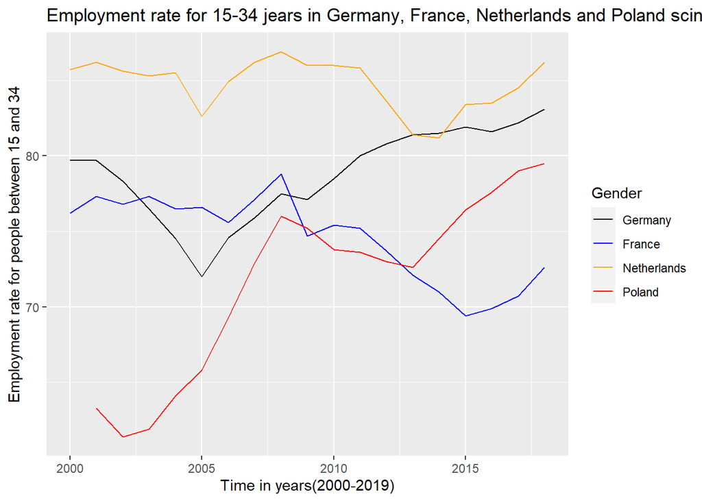

```r
ggplot() +
  geom_line(data = ger_merge, aes(x = year, y = eu_empl_durtotal_nuts0, color = "Germany")) +
  geom_line(data = fr_merge, aes(x = year, y = eu_empl_durtotal_nuts0, color = "France")) +
  geom_line(data = nl_merge, aes(x = year, y = eu_empl_durtotal_nuts0, color = "Netherlands")) +
  geom_line(data = pl_merge, aes(x = year, y = eu_empl_durtotal_nuts0, color = "Poland")) +
  scale_color_manual(name = "Gender", values = c("Germany" = "black", "France" = "blue", "Netherlands" = "orange", "Poland" = "red")) +
  ggtitle("Employment rate for 15-34 jears in Germany, France, Netherlands and Poland scince 2000") +
  xlab("Time in years(2000-2019)") +
  ylab("Employment rate for people between 15 and 34")
```

The generated diagram displayes the employment rate for people between the age of 15 and 34 in comparison for Germany, France, Netherlands and Poland over the time between 2000 and 2019. In the start the Employmentrate in Poland is the lowest while the Employmentrate in the Netherlands is the highest. Around 2002 the Rate in Poland increased and grows over 75. While after 2007 the Employmentrate in France decreased. The german Employmentrate in the beginning decreased till 2005. After 2005 the rate increased. In the end the Emplomentrate in the Netherlands is the highest followed by Germany and Poland while France has the lowest.

## 4. No educational attainment in Germany - written by Jan Pinto Strohhäusl

This part will show and discuss the percentage of people in Germany who have not graduated from primary school or completed lower secondary education.

### 4.1 Gather and tidy data

Like in the first part, we first start with loading the library `tidyverse`:

```r
library(tidyverse)
```

Then, we import our dataset, which is saved in the CSV-File:

```r
alldata2 <- read_csv("qog_eureg_wide1_nov20.csv")
```

Now, we have a variable called `alldata2`, which holds all the data from the imported dataset. However, to generate our diagram, we need to tidy it up, because there is data, which we will not use.  
First, we filter only the data that is related to Germany, because that is the data we are interested in:

```r
onlyGER2 <- filter(alldata2, region_name == "GERMANY")
```

Because here is data, that we also do not need, we then filter the columns to the columns we need. That would be the year and the values that hold the data about the percentage:

```r
filtered2 <- select(onlyGER2, year, eu_edatt_ed02_y2564f_nuts0:eu_edatt_ed02_y2564t_nuts0)
```

Now we still have columns, that are empty. The reason why there are columns that are empty is because how the dataset is set up. There are two seperate columns for each data: a column for the whole country (marked as “NUTS0”), and a column for a specific region in that country (marked as “NUTS1”). However, the dataset is set up in such a way, that each row takes both columns, creating null values. To accomodate this, we need to filter out the columns that are intended to use for regions. This is because we want to look at Germany as a whole, and are not in need of region specific data:

```r
filtered2 <- filtered2 %>% select(year, ends_with("nuts0"))
```

The final step now is to set the right time frame. The reason we do this is because there is only data available in a specific time frame, which is between 2000 and 2018. In order to set the right time frame, we need to filter again:

```r
final2 <- filter(filtered2, year >= 2000 & year < 2019)
```

The `final2`-variable now has year and the necessary columns saved, without any null values. Now we can generate a diagram for that dataframe.

### 4.2 Display diagram

Now that we have the data we need, we can create the diagram. I chose the `geom_line` style, because we want to look at a difference over time, and that is the style that is the most suitable for that kind of diagram.

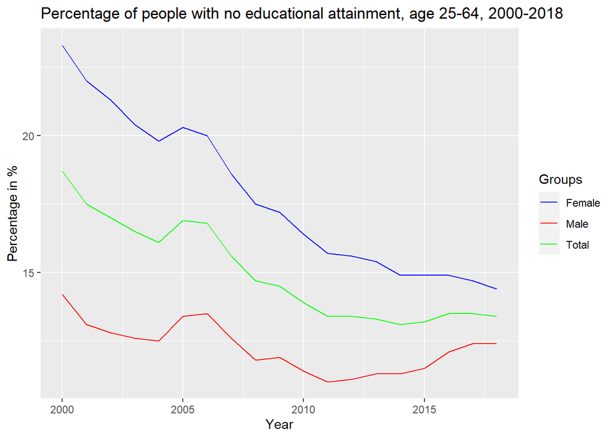

```r
ggplot(data = final2) +
    geom_line(mapping = aes(x = year, y = eu_edatt_ed02_y2564f_nuts0, color = "Female")) +
    geom_line(mapping = aes(x = year, y = eu_edatt_ed02_y2564m_nuts0, color = "Male")) +
    geom_line(mapping = aes(x = year, y = eu_edatt_ed02_y2564t_nuts0, color = "Total")) +
    xlab("Year") +
    ylab("Percentage in %") +
    ggtitle("Percentage of people with no educational attainment, age 25-64, 2000-2018") +
    scale_color_manual(name = "Groups", values = c("Female" = "blue", "Male" = "red", "Total" = "green"))
```

## 5. Employment rate in germany for Male and Female - written by Justus Reiffs

In this part the development of the Employmentrate for female and male is compared. Therefore the Employmentrate of 15-24 years old and 25-34 years old is compared in the time from 1999-2019.

### 5.1 Set up / Gather Data

To start the library is loaded. The libary used is the tidyvers libary because it is one of the most common ones.

```r
library(tidyverse)
```

Here the dataset is made available and read. After it has been imported to the info variable.

```r
info <- read.csv("qog_eureg_wide1_nov20.csv")
```

Here the data is filtered and tidyed so that only the relevant parts can be seen in the plot. The data gets limited for the german values and further selected foe the specific factors and the years that are under investigation.

```r
gerinfo <- filter(info, region_name == "GERMANY")

spec <- select(germaninfo, region_name, year)

ger_fil <- select(gerinfo, eu_emp_1524f_nuts0:eu_emp_2534t_nuts0)

ger_fil <- select(ger_fil, ends_with("nuts0"))

ger_merge <- bind_cols(spec, ger_fil)

ger_merge <- filter(ger_merge, year >= 1999 & year < 2019)
```

### 5.2 Display diagramm

In the following the plot is created using the ggplot.

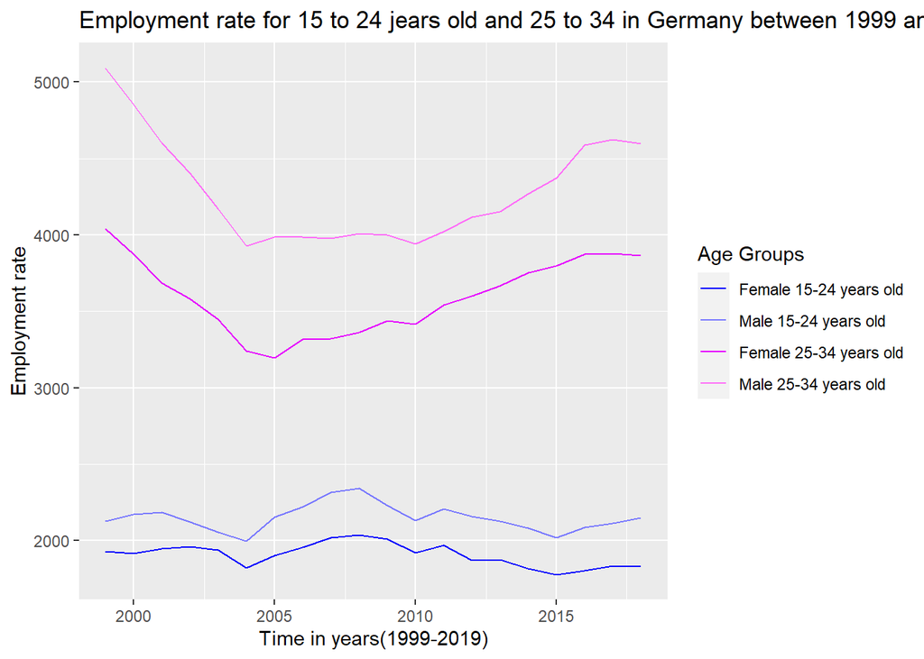

```r
ggplot(data = ger_merge) +
  geom_line(mapping = aes(x = year, y = eu_emp_1524f_nuts0, color = "Female 15-24 years old")) +
  geom_line(mapping = aes(x = year, y = eu_emp_1524m_nuts0, color = "Male 15-24 years old")) +
  geom_line(mapping = aes(x = year, y = eu_emp_2534f_nuts0, color = "Female 25-34 years old")) +
  geom_line(mapping = aes(x = year, y = eu_emp_2534m_nuts0, color = "Male 25-34 years old")) +
  scale_color_manual(name = "Age Groups", values = c("Female 15-24 years old" = "#0000ff", "Male 15-24 years old" = "#7979ff", "Female 25-34 years old" = "#e600ff", "Male 25-34 years old" = "#ff6ef8")) +
  ggtitle("Employment rate for 15 to 24 jears old and 25 to 34 in Germany between 1999 and 2019") +
  xlab("Time in years(1999-2019)") +
  ylab("Employment rate")
```

The diagram shows the Employmentrate for male and female in comparison of there gender and their age. The first age is 15 to 24 years old and the second is for 25 to 34 years old. The rate for the 25-34 years old in general is huger than the one for 15 to 34 years old. Also for both groups the rate for the female group is much lower than the rate for the male.

## 6. Higher education to income comparison in Germany - written by Jan Pinto Strohhäusl

This part will show and discuss how higher education and annual disposable income per inhabitant correlate together.

### 6.1 Gather and tidy data

We first start with loading the `tidyverse`-library:

```r
library(tidyverse)
```

Then, we import all the data from the CSV-File into out `alldata3`-variable:

```r
alldata3 <- read_csv("qog_eureg_wide1_nov20.csv")
```

When we loaded all the data, we then can start filtering the rows we need. Here, because we want to look at the regional differences in Germany, we need every row that holds regional data about Germany. So we first filter all rows that belongs to Germany, regardless of whether it is a regional row or a row about the whole country. Then, we delete all rows that holds data about the whole country, because these are not relevant to us:

```r
onlyGER3 <- alldata3[grep("DE", alldata3$region_code), ]

filtered3 <- onlyGER3[!grepl("GERMANY", onlyGER3$region_name), ]
```

Now we can filter all the rows we need. In our comparison, we need the region name, the year, the percentage of people between the ages of 25 - 64 that have completed a tertiary education and the average annual disposable income of each inhabitant:

```r
filtered3 <- select(filtered3, region_name, year, eu_edatt_ed58_y2564t_nuts1, eu_b6n_eur_hab_nuts1)
```

Now that we still have rows that do not hold data, we can filter them out. That results into a dataframe, that we use later to display the diagram:

```r
final3 <- filtered3 %>% filter_all(all_vars(!is.na(.)))
```

The `final3`-variable results into a dataframe which holds data to the topic from the years 2000 to 2017. To be sure that the values are indeed between 2000 to 2017, we can still filter them:

```r
final3 <- filter(final3, year >= 2000 & year < 2018)
```

### 6.2 Display diagram

The following code displays scatter plots. Each region in Germany has their own scatter plot, and there can be seen a change in every scatter plot over time:

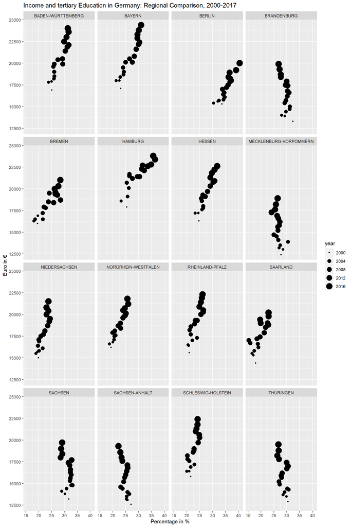

```r
ggplot(data = final3) +
    geom_point(mapping = aes(x = eu_edatt_ed58_y2564t_nuts1, y = eu_b6n_eur_hab_nuts1, size = year)) +
    facet_wrap(~region_name) +
    xlab("Percentage in %") +
    ylab("Euro in €") +
    ggtitle("Income and tertiary Education in Germany: Regional Comparison, 2000-2017")
```

# Part 2: Regression - written by Justus Reiffs and Jan Pinto Strohhäusl

The following part will include the regression analysis of both Justus and Jan. The author of each regression is clearly marked.

## Regression - written by Jan Pinto Strohhäusl

The following text, diagrams and code was created and written by Jan Pinto Strohhäusl.

This part will carry out the multivariate regression. Here, the dataframe `final3` of the scatter plots in the last part are used to perform the regression.

First, we load the needed library. Then, we will create a linear regression model of the dataframe by using the `lm()` command. Here, we define the percentage of people with high education as our dependent variable, while the year and the annual disposable income are the independent variables. After that, we generate the summary of that model:

```r
library(car)
regmodel <- lm(eu_edatt_ed58_y2564t_nuts1 ~ year + eu_b6n_eur_hab_nuts1, data = final3)

summary(regmodel)
```

```
##
## Call:
## lm(formula = eu_edatt_ed58_y2564t_nuts1 ~ year + eu_b6n_eur_hab_nuts1,
##     data = final3)
##
## Residuals:
##      Min       1Q   Median       3Q      Max
## -10.7639  -3.4945  -0.3449   3.0337  11.6805
##
## Coefficients:
##                        Estimate Std. Error t value Pr(>|t|)
## (Intercept)          -6.885e+02  1.382e+02  -4.981 1.10e-06 ***
## year                  3.584e-01  6.971e-02   5.141 5.08e-07 ***
## eu_b6n_eur_hab_nuts1 -2.761e-04  1.412e-04  -1.955   0.0516 .
## ---
## Signif. codes:  0 '***' 0.001 '**' 0.01 '*' 0.05 '.' 0.1 ' ' 1
##
## Residual standard error: 4.358 on 285 degrees of freedom
## Multiple R-squared:  0.1007, Adjusted R-squared:  0.09443
## F-statistic: 15.96 on 2 and 285 DF,  p-value: 2.681e-07
```

To make sure that the model does not have strong correlation, we use the following code:

```r
cor_matrix <- cor(final3[, c("year", "eu_edatt_ed58_y2564t_nuts1")])

print(cor_matrix)
```

```
##                                 year eu_edatt_ed58_y2564t_nuts1
## year                       1.0000000                  0.2978004
## eu_edatt_ed58_y2564t_nuts1 0.2978004                  1.0000000
```

Also, we need to check for strong collinearity. For this, we run the following code:

```r
vif(regmodel)
```

```
##                 year eu_b6n_eur_hab_nuts1
##             1.983151             1.983151
```

This outputs a weak collinearity between the independent variables. However, it is not a high value, because values between 1 and 5 show a weak, but not heavily significant collinearity. Therefore, this value can be considered acceptable.

Now we can have a more in-depth sight into the summary of the model. We first look into the Residuals vs Fitted diagram of that model. To generate that diagram, we run the following code:

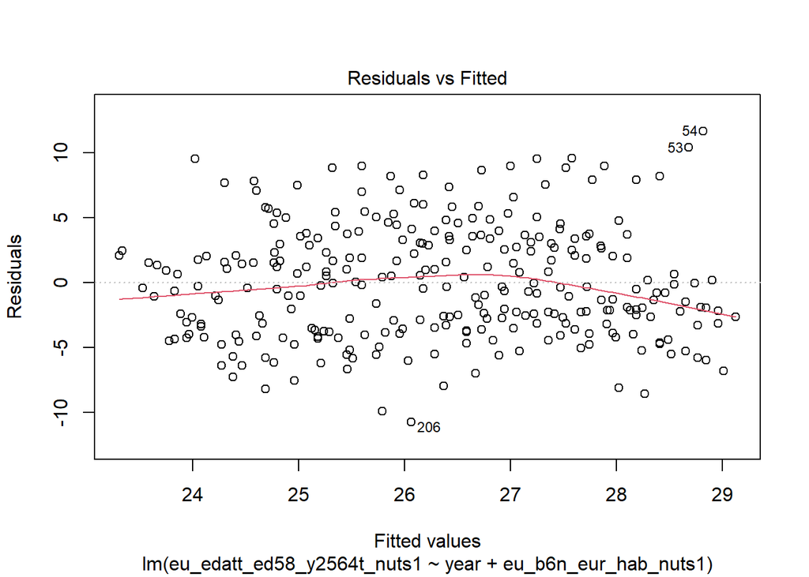

```r
plot(regmodel, which = 1)
```

As we can see, here is no obvious pattern by the red line, which indicates an almost perfect scenario. Also, the variance is constant, which can be seen by the residuals being randomly scattered around the horizontal line at zero.

We also check the normality assumption of our regression model. The following code generates the “Normal Q-Q” diagram:

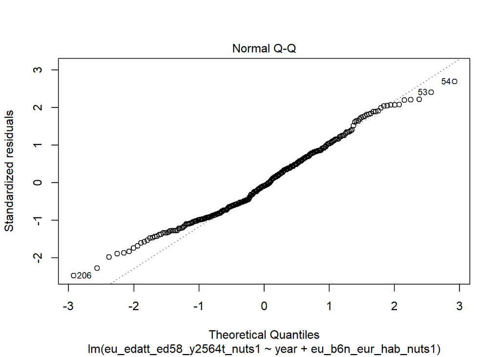

```r
plot(regmodel, which = 2)
```

We can also check the Homoscedasticity of the model by creating the following diagram:

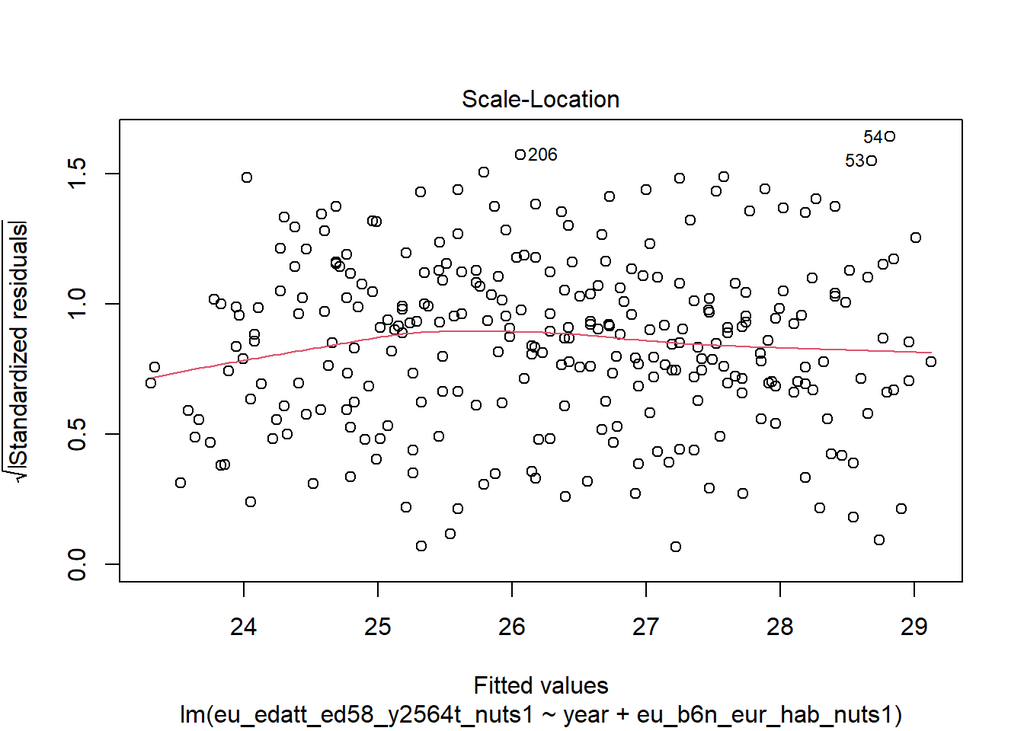

```r
plot(regmodel, which = 3)
```

As the diagram shows, the model is a homoscedastic model, because the residuals are again randomly scattered with no obvious pattern. This means that the homoscedasticity assumption is met, which means that variance of the residuals are constant, which also indicates that the model could be acceptable.

To sum all the regression up, the model is fitting for the data, even though the R-squared value in the summary is lower than what would be considered as acceptable.

## Regression - written by Justus Reiffs

### Collecting data

First the libraries are needed. Therefore the ggplot2 and tidyverse libary is loaded. This gives the possibility to use multiple commands and steps managing the data.

```r
library(ggplot2)
library(tidyverse)
```

Then the Dataset for the regression is read and stored in the variable “info”.

```r
info <- read.csv("qog_eureg_wide1_nov20.csv")
```

Then the model for linear regression is build. Therefore the variable model is used to store the “lm()” command. Inside that command the information is defined. Once we have the risk of poverty and the educational attainment. Also the information for the year and the dataset are included. Then the summary function will call a summary of that model.

```r
model <- lm(eu_povrisk_pc_nuts0 ~ eu_edatt_ed34_y2564t_nuts0 + year, data = info)

summary(model)
```

```
##
## Call:
## lm(formula = eu_povrisk_pc_nuts0 ~ eu_edatt_ed34_y2564t_nuts0 +
##     year, data = info)
##
## Residuals:
##    Min     1Q Median     3Q    Max
## -9.404 -3.030 -1.090  3.452 10.951
##
## Coefficients:
##                              Estimate Std. Error t value Pr(>|t|)
## (Intercept)                -338.03342   91.77678  -3.683 0.000257 ***
## eu_edatt_ed34_y2564t_nuts0   -0.03942    0.01324  -2.976 0.003067 **
## year                          0.17714    0.04564   3.882 0.000119 ***
## ---
## Signif. codes:  0 '***' 0.001 '**' 0.01 '*' 0.05 '.' 0.1 ' ' 1
##
## Residual standard error: 4.196 on 471 degrees of freedom
##   (7397 observations deleted due to missingness)
## Multiple R-squared:  0.04693,    Adjusted R-squared:  0.04289
## F-statistic:  11.6 on 2 and 471 DF,  p-value: 1.212e-05
```

The first result we we get is the output from the summary. First we get the call for the model. After the that residuals are given. The median has an value of -1.090 that is near to 0. also the min and max values are very close and only habe a difference in a view points. The coefficient values are as follows. The values here are less than 0.05 to. That indicates that there is an significand relationship between predictor variable and dependent variable. The low F-statistic and p-value indicates that the variables having an significant relationship as well.

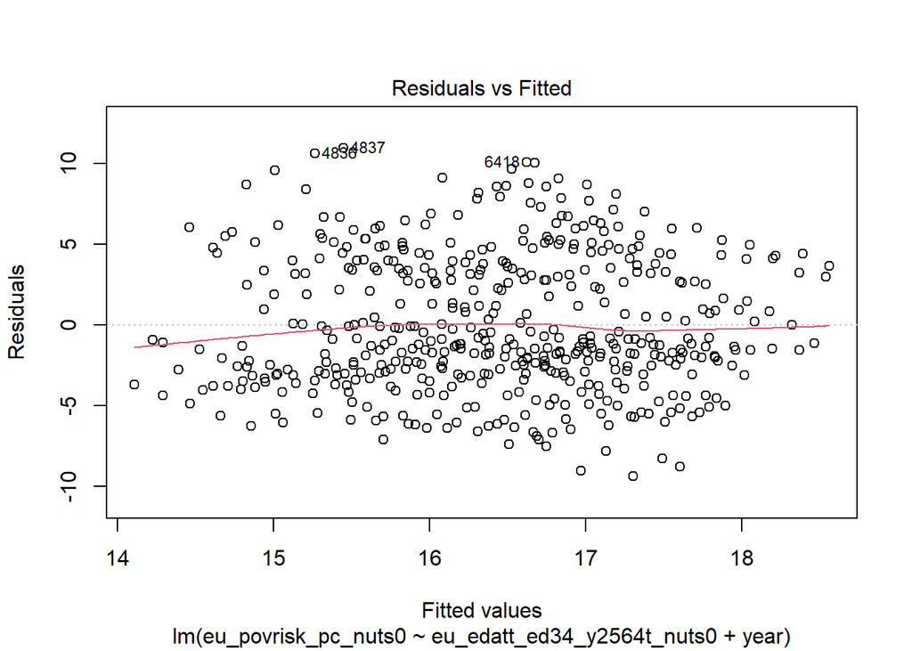

```r
plot(model, which = 1)
```

First we can analyse the Randomness of the diagramm. When the values are scattered around the horizontal line for zero is to suggest that the model is corectly capturing the relationship of those variabels. Second the constant variance is important. It is to see that there is an constant spread of residuals. That is called homoscedasticity and indicates an constant variance of the residants across the values.

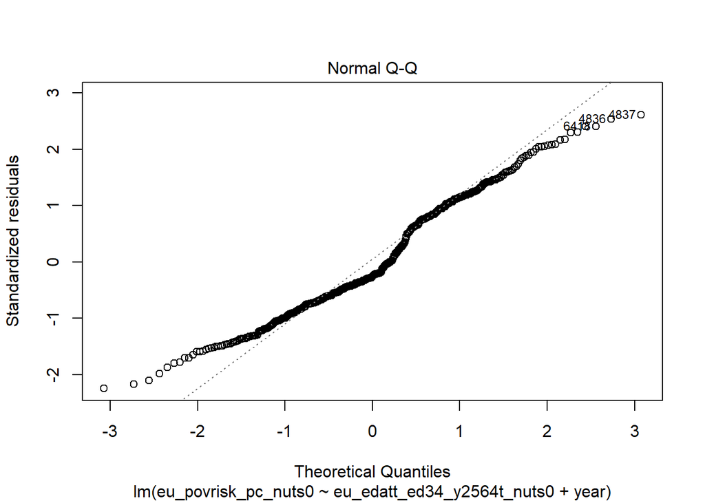

```r
plot(model, which = 2)
```

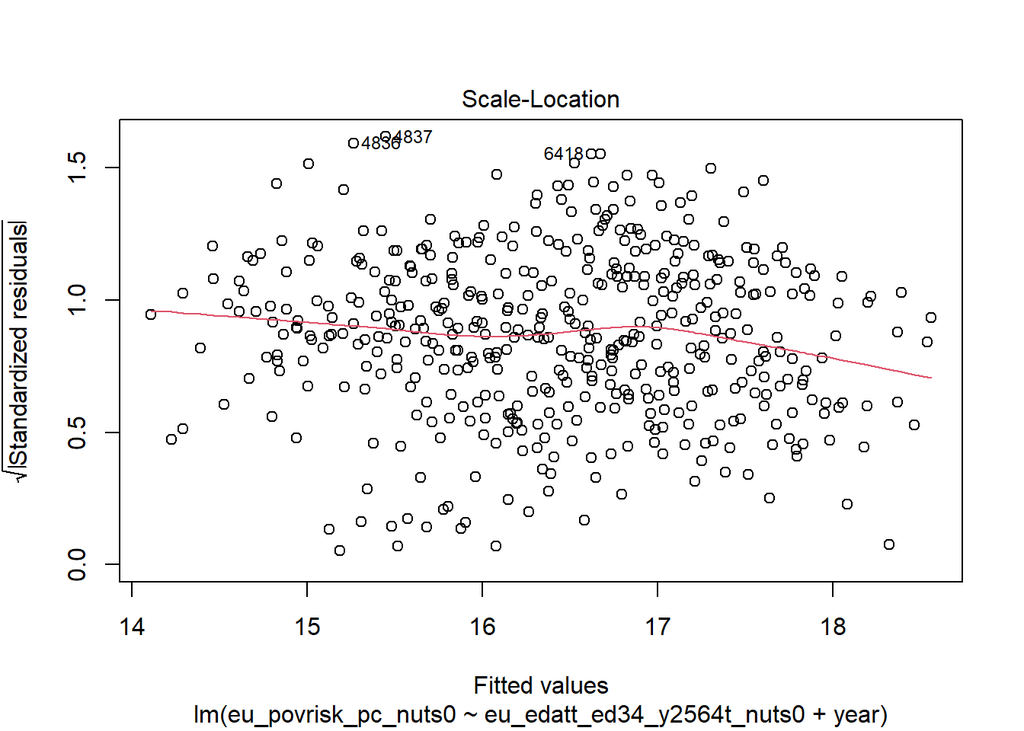

```r
plot(model, which = 3)
```

The diagram shows a wide spreaded field of the points this indicates no clear pattern. This indicates that the model correctly captures the relationship in the data. The constant variance is visible by its wide spread that indicates homoscedasticity and a constant variance across the values.

In the end it is to assume that the regression of that data was successful. The values are not perfect but still suitable for that regression to read the results from the generated diagramms.